# Getting Started

2018-11-05

The `rcaaqs` package strives to automate the calculation of CAAQS metrics outlined by the Canadian Council of Ministers of the Environment. All calculations are derived from the [Guidance Document on Achievement Determination Canadian Ambient Air Quality Standards for Fine Particulate Matter and Ozone](https://www.ccme.ca/files/Resources/air/aqms/pn_1483_gdad_eng.pdf) and [Methods for SO<sub>2</sub> and NO<sub>2</sub> outlined by Environmental Reporting BC](https://github.com/bcgov/rcaaqs/blob/master/inst/EnvReportBC_NO2andSO2_Methods_Nov2016.pdf)

See the section “Under the hood” for a better idea of how `rcaaqs` performs the underlying calculations.

## CAAQS metrics

There are 7 CAAQS metrics for 4 different pollutants, in the `rcaaqs` package each has a corresponding function:

- `pm_24h_caaqs()` - Fine Particulate Matter (PM2.5) over 24 hours (3-yr rolling average)
- `pm_annual_caaqs()` - Fine Particulate Matter (PM2.5) over a year (3-yr rolling average)
- `o3_caaqs()` - Ozone over 8 hours (3-yr rolling average)
- `so2_3yr_caaqs()` - SO<sub>2</sub> over 1 hour (3-yr rolling average)
- `so2_1yr_caaqs()` - SO<sub>2</sub> over a year
- `no2_3yr_caaqs()` - NO<sub>2</sub> over 1 hour (3-yr rolling average)
- `no2_1yr_caaqs()` - NO<sub>2</sub> over a year

While the underlying calculations are different, in general the procedure to calculate any given metric is similar. Therefore we will focus on Annual PM2.5.

Let’s start by loading some helpful packages

```r
# For plotting
library(ggplot2)

# For data manipulation
library(dplyr)
library(tidyr)

# For calculations
library(rcaaqs)
```

The `rcaaqs` package contains several sample data sets, let’s take a look at the PM2.5 sample data:

```r
head(pm25_sample_data)
```

```
#> # A tibble: 6 x 6
#>   ems_id  date_time           site                    year parameter value
#>   <chr>   <dttm>              <chr>                  <int> <chr>     <dbl>
#> 1 0220205 2011-03-01 00:59:59 Powell River Wildwood…  2011 PM25          2
#> 2 0220205 2011-03-01 01:59:59 Powell River Wildwood…  2011 PM25          2
#> 3 0220205 2011-03-01 02:59:59 Powell River Wildwood…  2011 PM25          0
#> 4 0220205 2011-03-01 03:59:59 Powell River Wildwood…  2011 PM25          3
#> 5 0220205 2011-03-01 04:59:59 Powell River Wildwood…  2011 PM25          1
#> 6 0220205 2011-03-01 05:59:59 Powell River Wildwood…  2011 PM25          1
```

The `clean_neg()` and `date_fill()` are useful helper functions for ensuring all the pollutant values are positive or zero, and that you are starting with a complete dataframe (i.e. no missing hourly readings):

```r
pm25_sample_data <- pm25_sample_data %>%
  mutate(value = clean_neg(value, type = "pm25"))

pm25_sample_data <- pm25_sample_data %>%
  group_by(ems_id, site) %>%
  do(., date_fill(., date_col = "date_time",
                  fill_cols = c("ems_id", "site"),
                  interval = "1 hour")) %>%
  ungroup()

head(pm25_sample_data)
```

```
#> # A tibble: 6 x 6
#>   date_time           ems_id  site                    year parameter value
#>   <dttm>              <chr>   <chr>                  <int> <chr>     <dbl>
#> 1 2011-03-01 00:59:59 0220205 Powell River Wildwood…  2011 PM25          2
#> 2 2011-03-01 01:59:59 0220205 Powell River Wildwood…  2011 PM25          2
#> 3 2011-03-01 02:59:59 0220205 Powell River Wildwood…  2011 PM25          0
#> 4 2011-03-01 03:59:59 0220205 Powell River Wildwood…  2011 PM25          3
#> 5 2011-03-01 04:59:59 0220205 Powell River Wildwood…  2011 PM25          1
#> 6 2011-03-01 05:59:59 0220205 Powell River Wildwood…  2011 PM25          1
```

Calculating a CAAQS metric is straightforward. Just make sure you include grouping variables (i.e. station information in our case here)

```r
pm <- pm_annual_caaqs(pm25_sample_data,
                     by = c("ems_id", "site"))
pm
```

```
#> # A tibble: 30 x 14
#>    ems_id site  caaqs_year min_year max_year n_years metric metric_value
#>    <chr>  <chr>      <dbl>    <dbl>    <dbl>   <dbl> <chr>         <dbl>
#>  1 02202… Powe…       2011     2011     2011       0 pm2.5…         NA
#>  2 02202… Powe…       2012     2012     2012       1 pm2.5…         NA
#>  3 02202… Powe…       2013     2012     2013       1 pm2.5…         NA
#>  4 03101… Port…       2011     2011     2011       1 pm2.5…         NA
#>  5 03101… Port…       2012     2011     2012       2 pm2.5…          4.6
#>  6 03101… Port…       2013     2011     2013       3 pm2.5…          5.1
#>  7 03101… Squa…       2011     2011     2011       1 pm2.5…         NA
#>  8 03101… Squa…       2012     2011     2012       2 pm2.5…          6.6
#>  9 03101… Squa…       2013     2011     2013       3 pm2.5…          6.5
#> 10 03101… Vanc…       2011     2011     2011       1 pm2.5…         NA
#> # ... with 20 more rows, and 6 more variables: caaqs <ord>, mgmt <ord>,
#> #   excluded <lgl>, flag_daily_incomplete <lgl>,
#> #   flag_yearly_incomplete <lgl>, flag_two_of_three_years <lgl>
```

Besides the actual CAAQS metric values (`metric_value`), there are several important columns.

**CAAQS details**

- `caaqs_year` - The year for which the CAAQS metric is compiled
- `min_year` & `max_year` - The first year and last years included in the rolling average (in this example)
- `n_years` - The total number of years included in a metric. Note that `metric_values` are NA for any year that has < 2 years included

**CAAQS values**

- `metric` - The name of the metric calculated
- `metric_value` - The actual CAAQS metric, calculated and rounded according to the documentation
- `caaqs` - The ‘achievement’ level of the CAAQS metric
- `mgmt` - The ‘management’ level of the CAAQS metric

**Data Exclusion**

- `excluded` - Whether any days were excluded due to Exceptional Events or Transboundary Flows (see below)

**Data completeness**

- `flag_daily_incomplete` - Whether any of the daily summaries were kept, but flagged as incomplete
- `flag_yearly_incomplete` - Whether any of the yearly summaries were kept, but flagged as incomplete
- `flag_two_of_three_years` - Whether the 3-yr rolling average is based on only 2 years

Note that in all cases values of `NA` indicate that flagging didn’t apply to this metric (see CAAQS Documentation for more details)

## Excluding dates based on Exceptional Events or Transboundary Flows

First let’s take a look at the daily averages, to do this, we need to re-run our CAAQS analysis, but retain intermediate data:

```r
pm <- pm_annual_caaqs(pm25_sample_data,
                     by = c("ems_id", "site"),
                     return_all = TRUE)

pm
```

```
#> # A tibble: 10 x 6
#>    ems_id  site         daily_avg    yearly_avg  three_yr_rolling caaqs
#>    <chr>   <chr>        <list>       <list>      <list>           <list>
#>  1 0220205 Powell Rive… <tibble [1,… <tibble [3… <tibble [3 × 20… <tibble…
#>  2 0310162 Port Moody … <tibble [1,… <tibble [3… <tibble [3 × 20… <tibble…
#>  3 0310172 Squamish Go… <tibble [1,… <tibble [3… <tibble [3 × 20… <tibble…
#>  4 0310175 Vancouver K… <tibble [1,… <tibble [3… <tibble [3 × 20… <tibble…
#>  5 0310177 Burnaby Ken… <tibble [1,… <tibble [3… <tibble [3 × 20… <tibble…
#>  6 0310179 North Vanco… <tibble [1,… <tibble [3… <tibble [3 × 20… <tibble…
#>  7 0450270 Prince Geor… <tibble [1,… <tibble [3… <tibble [3 × 20… <tibble…
#>  8 0450307 Prince Geor… <tibble [1,… <tibble [3… <tibble [3 × 20… <tibble…
#>  9 0500886 Kelowna Col… <tibble [1,… <tibble [3… <tibble [3 × 20… <tibble…
#> 10 0550502 Williams La… <tibble [1,… <tibble [3… <tibble [3 × 20… <tibble…
```

To explore any of these sub-data sets individually you can unnest the data (using the `unnest()` function from the `tidyr` package):

```r
pm_daily_avg <- unnest(pm, daily_avg)
pm_daily_avg
```

```
#> # A tibble: 10,901 x 8
#>    ems_id site  date       n_readings valid avg_24h exceed flag_daily_inc…
#>    <chr>  <chr> <date>          <int> <lgl>   <dbl> <lgl>  <lgl>
#>  1 02202… Powe… 2011-03-01         24 TRUE      1   FALSE  NA
#>  2 02202… Powe… 2011-03-02         22 TRUE      2.3 FALSE  NA
#>  3 02202… Powe… 2011-03-03         24 TRUE      2   FALSE  NA
#>  4 02202… Powe… 2011-03-04         24 TRUE      1   FALSE  NA
#>  5 02202… Powe… 2011-03-05         24 TRUE      1.6 FALSE  NA
#>  6 02202… Powe… 2011-03-06         24 TRUE      1   FALSE  NA
#>  7 02202… Powe… 2011-03-07         24 TRUE      1.6 FALSE  NA
#>  8 02202… Powe… 2011-03-08         24 TRUE      2.2 FALSE  NA
#>  9 02202… Powe… 2011-03-09         23 TRUE      1.3 FALSE  NA
#> 10 02202… Powe… 2011-03-10         24 TRUE      2.6 FALSE  NA
#> # ... with 10,891 more rows
```

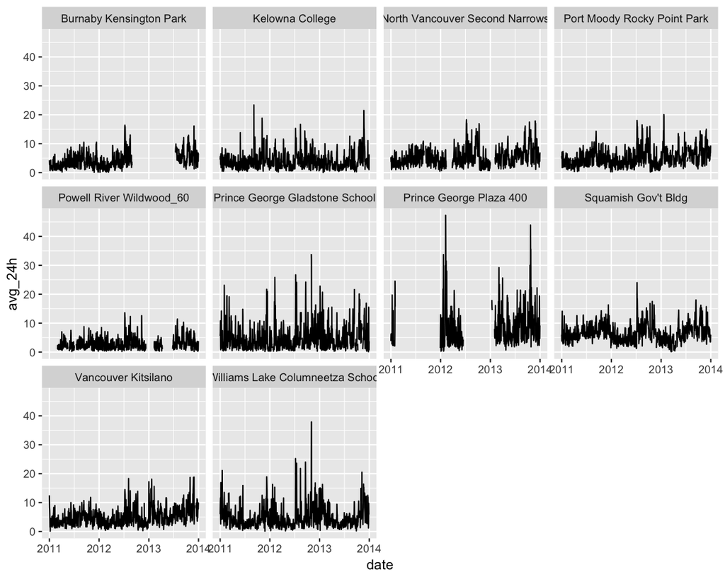

```r
ggplot(data = pm_daily_avg, aes(x = date, y = avg_24h)) +
  geom_line() +
  facet_wrap(~ site)
```

Let’s say, for illustration purposes, that all high values in the summer of 2012 were due to forest fires and we want to exclude them.

We’ll `filter()` the daily data to just these dates and `select()` only the columns that reflect the grouping of our data and the dates.

```r
high_dates <- pm_daily_avg %>%
  filter(date >= as.Date("2012-05-01"),
         date < as.Date("2012-10-01"),
         avg_24h > 10) %>%
  select(ems_id, site, date)
high_dates
```

```
#> # A tibble: 144 x 3
#>    ems_id  site                        date
#>    <chr>   <chr>                       <date>
#>  1 0220205 Powell River Wildwood_60    2012-07-08
#>  2 0220205 Powell River Wildwood_60    2012-07-09
#>  3 0220205 Powell River Wildwood_60    2012-07-10
#>  4 0220205 Powell River Wildwood_60    2012-08-18
#>  5 0310162 Port Moody Rocky Point Park 2012-07-06
#>  6 0310162 Port Moody Rocky Point Park 2012-07-07
#>  7 0310162 Port Moody Rocky Point Park 2012-07-08
#>  8 0310162 Port Moody Rocky Point Park 2012-07-09
#>  9 0310162 Port Moody Rocky Point Park 2012-07-10
#> 10 0310162 Port Moody Rocky Point Park 2012-07-11
#> # ... with 134 more rows
```

Now we can pass this on to our caaqs function with the `exclude_df` argument, which specifies the data frame, and the `exclude_df_dt` which specifies the name of the column holding the dates.

```r
pm_excl <- pm_annual_caaqs(pm25_sample_data,
                          by = c("ems_id", "site"),
                          return_all = TRUE,
                          exclude_df = high_dates,
                          exclude_df_dt = "date")

pm_excl_caaqs <- unnest(pm_excl, caaqs)
pm_excl_caaqs
```

```
#> # A tibble: 30 x 14
#>    ems_id site  caaqs_year min_year max_year n_years metric metric_value
#>    <chr>  <chr>      <dbl>    <dbl>    <dbl>   <dbl> <chr>         <dbl>
#>  1 02202… Powe…       2011     2011     2011       0 pm2.5…         NA
#>  2 02202… Powe…       2012     2012     2012       1 pm2.5…         NA
#>  3 02202… Powe…       2013     2012     2013       1 pm2.5…         NA
#>  4 03101… Port…       2011     2011     2011       1 pm2.5…         NA
#>  5 03101… Port…       2012     2011     2012       2 pm2.5…          4.3
#>  6 03101… Port…       2013     2011     2013       3 pm2.5…          5
#>  7 03101… Squa…       2011     2011     2011       1 pm2.5…         NA
#>  8 03101… Squa…       2012     2011     2012       2 pm2.5…          6.3
#>  9 03101… Squa…       2013     2011     2013       3 pm2.5…          6.3
#> 10 03101… Vanc…       2011     2011     2011       1 pm2.5…         NA
#> # ... with 20 more rows, and 6 more variables: caaqs <ord>, mgmt <ord>,
#> #   excluded <lgl>, flag_daily_incomplete <lgl>,
#> #   flag_yearly_incomplete <lgl>, flag_two_of_three_years <lgl>
```

Note that the `excluded` column now has some `TRUE` values, reflect the fact that some dates in that metric have been excluded. (Note that excluding data in this manner does not influence the evaluation of data completeness).

We can also define excluded dates with date ranges, but here we must specify both start and end column names:

```r
high_dates <- data.frame(ems_id = "0310162",
                         site = "Port Moody Rocky Point Park",
                         start = as.Date(c("2012-06-11", "2012-07-01")),
                         end = as.Date(c("2012-06-25", "2012-08-14")))
high_dates
```

```
#>    ems_id                        site      start        end
#> 1 0310162 Port Moody Rocky Point Park 2012-06-11 2012-06-25
#> 2 0310162 Port Moody Rocky Point Park 2012-07-01 2012-08-14
```

```r
pm_excl <- pm_annual_caaqs(pm25_sample_data,
                          by = c("ems_id", "site"),
                          return_all = TRUE,
                          exclude_df = high_dates,
                          exclude_df_dt = c("start", "end"))

pm_excl_caaqs <- unnest(pm_excl, caaqs)
pm_excl_caaqs
```

```
#> # A tibble: 30 x 14
#>    ems_id site  caaqs_year min_year max_year n_years metric metric_value
#>    <chr>  <chr>      <dbl>    <dbl>    <dbl>   <dbl> <chr>         <dbl>
#>  1 02202… Powe…       2011     2011     2011       0 pm2.5…         NA
#>  2 02202… Powe…       2012     2012     2012       1 pm2.5…         NA
#>  3 02202… Powe…       2013     2012     2013       1 pm2.5…         NA
#>  4 03101… Port…       2011     2011     2011       1 pm2.5…         NA
#>  5 03101… Port…       2012     2011     2012       2 pm2.5…          4.5
#>  6 03101… Port…       2013     2011     2013       3 pm2.5…          5.1
#>  7 03101… Squa…       2011     2011     2011       1 pm2.5…         NA
#>  8 03101… Squa…       2012     2011     2012       2 pm2.5…          6.6
#>  9 03101… Squa…       2013     2011     2013       3 pm2.5…          6.5
#> 10 03101… Vanc…       2011     2011     2011       1 pm2.5…         NA
#> # ... with 20 more rows, and 6 more variables: caaqs <ord>, mgmt <ord>,
#> #   excluded <lgl>, flag_daily_incomplete <lgl>,
#> #   flag_yearly_incomplete <lgl>, flag_two_of_three_years <lgl>
```

## Under the hood

To understand what’s happening within the CAAQS functions we can take a look at this function flow chart:

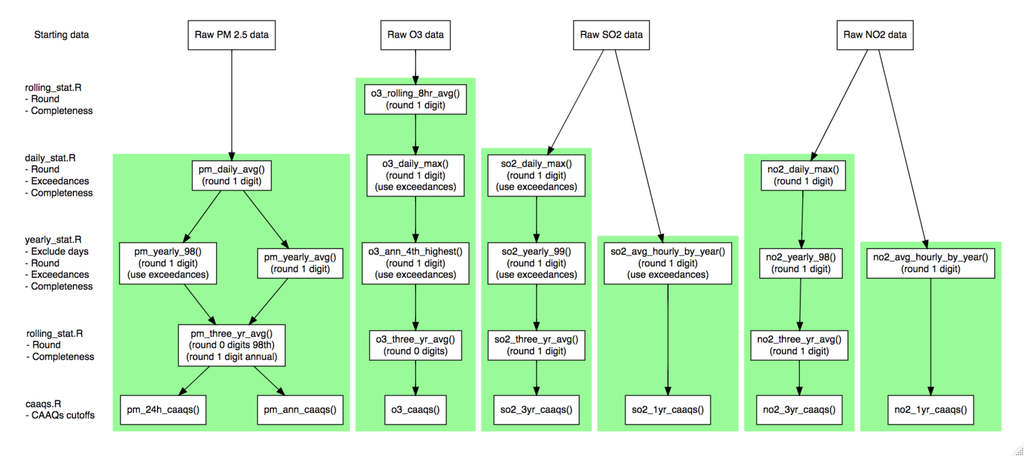

Each step from the documentation has a corresponding function (or functions) in the `rcaaqs` package, but most of these are hidden. The green boxes reflect the wrapper CAAQS functions that perform all the underlying steps. For example, the `o3_caaqs()` function performs all the steps outlined in the second green column.

## Airzones

We can match our data to an airzone by using the `assign_airzones()` function but you must have the following:

- A map file reflecting airzones, specifically a SpatialPolygonsDataFrame
- CAAQS data with latitude and longitude for each station/site

For the following examples, we’ll use our `pm` CAAQS data, but only for 2013

```r
pm_caaqs <- unnest(pm, caaqs) %>%
  filter(caaqs_year == 2013)
```

We will get our map file from the [`bcmaps` package](https://github.com/bcgov/bcmaps) (note that you must also install the [`bcmaps.rdata package`](https://github.com/bcgov/bcmaps#usage)).

```r
library(bcmaps)
az <- bcmaps::airzones(class = "sp")
class(az)
```

```
#> [1] "SpatialPolygonsDataFrame"
#> attr(,"package")
#> [1] "sp"
```

```r
az@data
```

```
#>               Airzone
#> 1           Northeast
#> 2           Northwest
#> 3   Southern Interior
#> 4 Lower Fraser Valley
#> 5    Central Interior
#> 6             Coastal
#> 7      Georgia Strait
```

We’ll get our stations coordinates from an online list

```r
url <- "ftp://ftp.env.gov.bc.ca/pub/outgoing/AIR/Air_Monitoring_Stations/bc_air_monitoring_stations.csv"

stations <- readr::read_csv(url, na = "N/A") %>%  # Download csv file
  rename_all(tolower) %>%                         # Rename columns to lower case
  filter(ems_id %in% unique(pm$ems_id)) %>%       # Filter to ids in our pm data
  select(ems_id, latitude, longitude) %>%         # Select only the important columns
  mutate(latitude = as.numeric(latitude),         # Transform lat and lon to numeric
         longitude = as.numeric(longitude)) %>%
  distinct()                                      # Remove any duplicates

stations
```

```
#> # A tibble: 10 x 3
#>    ems_id  latitude longitude
#>    <chr>      <dbl>     <dbl>
#>  1 0310177     49.3     -123.
#>  2 0500886     49.9     -119.
#>  3 0310179     49.3     -123.
#>  4 0310162     49.3     -123.
#>  5 0220205     49.9     -125.
#>  6 0450270     53.9     -123.
#>  7 0450307     53.9     -123.
#>  8 0310172     49.7     -123.
#>  9 0310175     49.3     -123.
#> 10 0550502     52.1     -122.
```

Now we’ll merge them into our CAAQS data

```r
pm_caaqs <- left_join(pm_caaqs, stations, by = "ems_id")
pm_caaqs
```

```
#> # A tibble: 10 x 16
#>    ems_id site  caaqs_year min_year max_year n_years metric metric_value
#>    <chr>  <chr>      <dbl>    <dbl>    <dbl>   <dbl> <chr>         <dbl>
#>  1 02202… Powe…       2013     2012     2013       1 pm2.5…         NA
#>  2 03101… Port…       2013     2011     2013       3 pm2.5…          5.1
#>  3 03101… Squa…       2013     2011     2013       3 pm2.5…          6.5
#>  4 03101… Vanc…       2013     2011     2013       3 pm2.5…          5
#>  5 03101… Burn…       2013     2011     2013       1 pm2.5…         NA
#>  6 03101… Nort…       2013     2011     2013       2 pm2.5…          5.4
#>  7 04502… Prin…       2013     2011     2013       3 pm2.5…          4.6
#>  8 04503… Prin…       2013     2013     2013       1 pm2.5…         NA
#>  9 05008… Kelo…       2013     2011     2013       3 pm2.5…          4
#> 10 05505… Will…       2013     2011     2013       3 pm2.5…          4.8
#> # ... with 8 more variables: caaqs <ord>, mgmt <ord>, excluded <lgl>,
#> #   flag_daily_incomplete <lgl>, flag_yearly_incomplete <lgl>,
#> #   flag_two_of_three_years <lgl>, latitude <dbl>, longitude <dbl>
```

Now we have our airzones map and our station coordinates, we can match stations to airzones:

```r
pm_az <- assign_airzone(pm_caaqs, airzones = az, coords = c("latitude", "longitude"))
pm_az
```

```
#> # A tibble: 10 x 17
#>    ems_id site  caaqs_year min_year max_year n_years metric metric_value
#>    <chr>  <chr>      <dbl>    <dbl>    <dbl>   <dbl> <chr>         <dbl>
#>  1 02202… Powe…       2013     2012     2013       1 pm2.5…         NA
#>  2 03101… Port…       2013     2011     2013       3 pm2.5…          5.1
#>  3 03101… Squa…       2013     2011     2013       3 pm2.5…          6.5
#>  4 03101… Vanc…       2013     2011     2013       3 pm2.5…          5
#>  5 03101… Burn…       2013     2011     2013       1 pm2.5…         NA
#>  6 03101… Nort…       2013     2011     2013       2 pm2.5…          5.4
#>  7 04502… Prin…       2013     2011     2013       3 pm2.5…          4.6
#>  8 04503… Prin…       2013     2013     2013       1 pm2.5…         NA
#>  9 05008… Kelo…       2013     2011     2013       3 pm2.5…          4
#> 10 05505… Will…       2013     2011     2013       3 pm2.5…          4.8
#> # ... with 9 more variables: caaqs <ord>, mgmt <ord>, excluded <lgl>,
#> #   flag_daily_incomplete <lgl>, flag_yearly_incomplete <lgl>,
#> #   flag_two_of_three_years <lgl>, lat <dbl>, lon <dbl>, airzone <chr>
```

```r
pm_az2 <- airzone_metric(pm_az)
pm_az2
```

```
#> # A tibble: 4 x 5
#>   airzone        n_years metric_value caaqs   mgmt
#>   <chr>            <dbl>        <dbl> <ord>   <ord>
#> 1 Central Inter…       3          4.8 Achiev… Actions for Preventing Air …
#> 2 Georgia Strait       3          6.5 Achiev… Actions for Preventing CAAQ…
#> 3 Lower Fraser …       2          5.4 Achiev… Actions for Preventing Air …
#> 4 Southern Inte…       3          4   Achiev… Actions for Keeping Clean A…
```

## Mapping airzones

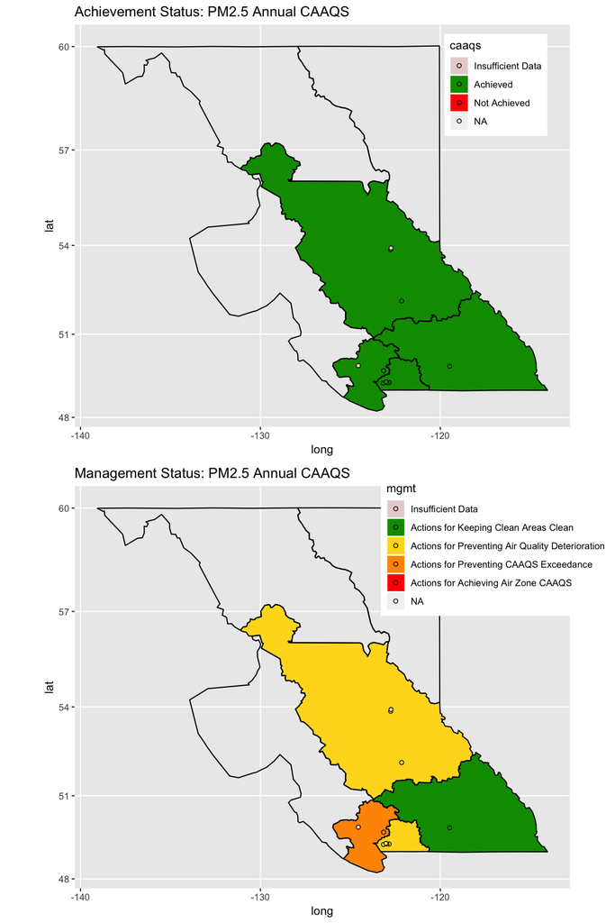

```r
library(sp)
library(gridExtra)

az_plot <- spTransform(az, CRS("+proj=longlat"))
az_plot <- fortify(az_plot, region = "Airzone") %>%
  left_join(pm_az2, by = c("id" = "airzone"))

g1 <- ggplot(data = az_plot, aes(x = long, y = lat, group = group)) +
  theme(legend.position = c(0.85, 0.85)) +
  coord_map() +
  geom_polygon(aes(fill = caaqs)) +
  geom_path(colour = "black") +
  geom_point(data = pm_az, shape = 21, colour = "black",
             aes(x = lon, y = lat, fill = caaqs),
             inherit.aes = FALSE) +
  scale_fill_manual(values = get_colours(type = "achievement"), drop = FALSE) +
  labs(title = "Achievement Status: PM2.5 Annual CAAQS")

g2 <- ggplot(data = az_plot, aes(x = long, y = lat, group = group)) +
  theme(legend.position = c(0.85, 0.85)) +
  coord_map() +
  geom_polygon(aes(fill = mgmt)) +
  geom_path(colour = "black") +
  geom_point(data = pm_az, shape = 21, colour = "black",
             aes(x = lon, y = lat, fill = mgmt),
             inherit.aes = FALSE) +
  scale_fill_manual(values = get_colours(type = "management"), drop = FALSE) +
  labs(title = "Management Status: PM2.5 Annual CAAQS")

grid.arrange(g1, g2, ncol = 1)
```